# Від чого залежить ціна діаманта

Лабораторна №3 · Регресійне моделювання · набір Diamonds

Демчук Владислав

## Що я досліджував

- Головне питання: чи можна вгадати ціну діаманта, знаючи лише чотири характеристики з його сертифіката — вагу, огранку, колір і чистоту?
- Друге питання: на скільки дорожчає камінь, коли він важчий, а якість та сама?
- Дані: 53 748 діамантів з онлайн-каталогу 2008 року (набір diamonds з пакета ggplot2). Ціна — у доларах.

## Як я перевіряв

- Одразу розділив дані: 80 % каменів — для навчання моделей, 20 % сховав для фінальної перевірки (поділ випадковий, seed = 42).
- Моделі порівнював лише на навчальній частині: 5 разів навчав на 4/5 даних і перевіряв на решті (перехресна валідація).
- Головна міра якості — MAE: на скільки доларів у середньому помиляється прогноз. Чим менше, тим краще.

## Мої здогадки (гіпотези)

- H1. Ціна росте швидше за вагу: камінь удвічі важчий коштує більш ніж удвічі дорожче (Chu, 2001).
- H2. Чим чистіший камінь, тим він дорожчий; найчистіший (IF) щонайменше вдвічі дорожчий за найгірший (I1).
- Ще одна підказка з літератури: ціна стрибає на «круглих» вагах — 0,5, 1, 1,5 і 2 карата (Scott і Yelowitz, 2010).
- Здогадки підказали ті самі дані в лаб. №2, тому перевірка попередня (розвідувальна).

## Що показали дані

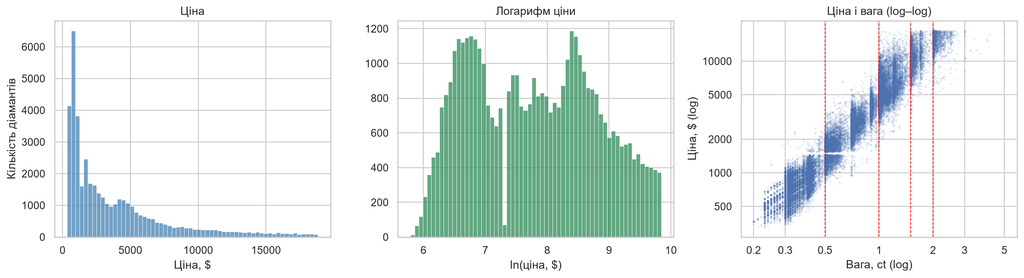

## Перша модель і перевірка її помилок

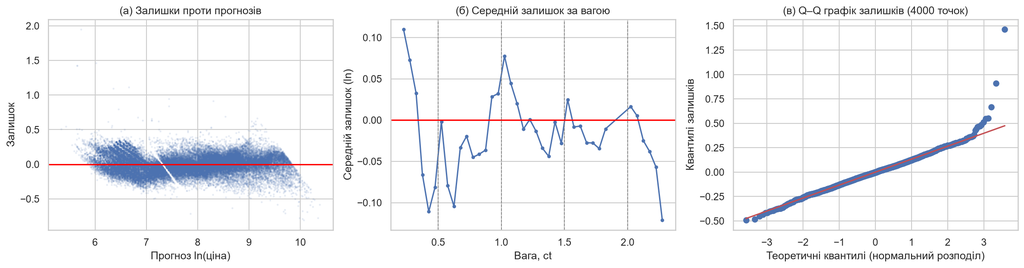

- Проста формула в доларах (M1) погана: 4061 каменів отримали від’ємну ціну. Тому беру формулу з логарифмами (M2): вона пояснює 98 % розкиду цін.
- Графік (б): модель помиляється біля круглих ваг, тож у наступній моделі (M3) додаю «сходинки» ваги.
- Окремі незвичні камені результат не псують (максимальна відстань Кука 0,027).

## Чи підтвердились здогадки

- H1 — так. Камінь на 1 % важчий коштує на 1,88 % дорожче (95 % довірчий інтервал 1,881–1,887). Удвічі важчий — приблизно в 3,7 раза дорожчий.
- H2 — так. Ціна росте з кожним кращим рівнем чистоти; IF дорожча за I1 на 204 % (інтервал 198–211 %).
- Для порівняння: найкращий колір додає 67 %, а найкраща огранка — лише 18 %.
- Кожна надбавка — для каменів, у яких усі інші характеристики однакові.

## Порівняння шести моделей

| Модель | Середня помилка, $ |
| --- | --- |
| M0 — завжди називає середню ціну | 3041 ± 23 |
| M1 — проста формула в доларах | 804 ± 5 |
| M2 — формула з логарифмами | 404 ± 6 |
| M3 — M2 + «сходинки» на круглих вагах | 370 ± 5 |
| M4 — M3 + колір і чистота разом | 340 ± 3 |
| M5 — бустинг (багато дерев рішень) | 289 ± 2 |

- Чим нижче в таблиці, тим точніша модель. «±» — наскільки помилка коливається між п’ятьма перевірками.
- Правило вибору я записав заздалегідь: найменша помилка. Тому для прогнозу — бустинг (M5).
- Для пояснення зв’язків беру формулу (M4), бо бустинг не дає зрозумілих коефіцієнтів.

## Фінальна перевірка на схованих 20 %

| Модель | Середня помилка, $ | Типова помилка, % |
| --- | --- | --- |
| M0 — середня ціна | 2990 | 74,6 |
| M5 — бустинг (обрана) | 289 | 6,2 |
| M4 — найкраща формула | 341 | 7,4 |

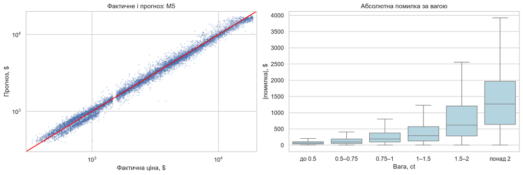

- Бустинг помиляється в середньому на 289 $ (близько 6 % ціни), а «завжди середня ціна» — на 2990 $.
- Найбільші помилки — у великих дорогих каменях: 11 % каменів дають 39 % усієї помилки.

## Висновки

- Чотири характеристики з сертифіката дозволяють вгадати ціну з помилкою близько 6 %.
- Найбільше на ціну впливає вага; серед якісних характеристик — чистота, найменше — огранка.
- Це зв’язки в даних, а не причини: дані лише спостерігались.
- Обмеження: дані 2008 року, один ринок, лише круглі камені, ціни до 18 823 $.
- Що далі: перевірити модель на свіжих даних з кількох магазинів.

Дякую за увагу!